# Lecture 9: Central Limit Theorem

## STAT 324

### Ralph Trane

### University of Wisconsin–Madison<br><br>

### Spring 2020

# Previously on STAT 324...

**Scenario 1:**

The data (i.e. `\(X_1, ..., X_n\)`) are normally distributed, independent, and **we know** `\(\sigma\)`. Then

$$
  \bar{X} \sim N(\mu, \sigma^2/n) \qquad \text{and} \qquad \frac{\bar{X} -\mu}{\sigma/\sqrt{n}} \sim N(0,1),
$$

so

`$$P\left(\bar{X} - z_{\alpha/2}\frac{\sigma}{\sqrt{n}} < \mu < \bar{X} + z_{\alpha/2}\frac{\sigma}{\sqrt{n}}\right) = 1 - \alpha$$`

where `\(z_{\alpha/2}\)` is the number such that `\(P(Z > z_{\alpha/2}) = \alpha/2\)`

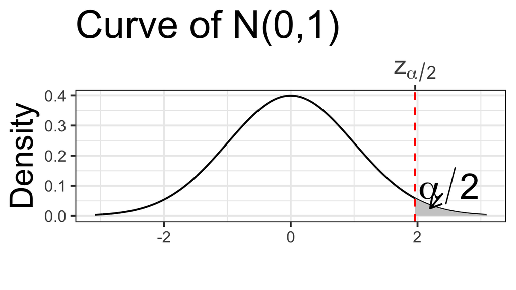

**Scenario 2:**

The data (i.e. `\(X_1, ..., X_n\)`) are normally distributed, independent, but we **do not** know `\(\sigma\)`. Then

$$
  \bar{X} \sim N(\mu, \sigma^2/n) \qquad \text{and} \qquad \frac{\bar{X} -\mu}{s/\sqrt{n}} \sim t_{n-1},
$$

so

`$$P\left(\bar{X} - t_{n-1,\alpha/2}\frac{s}{\sqrt{n}} < \mu < \bar{X} + t_{n-1,\alpha/2}\frac{s}{\sqrt{n}}\right) = 1 - \alpha$$`

where `\(t_{n-1,\alpha/2}\)` is the number such that `\(P(T_{n-1} > t_{n-1,\alpha/2}) = \alpha/2\)`

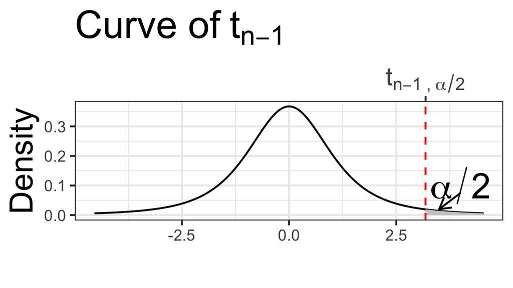

Recall: paint thickness data.

```r
library(tidyverse); library(distributions3)
paint_thickness <- tibble(
  thickness = c(1.29, 1.12, 0.88, 1.65, 1.48, 1.59, 1.04, 0.83,
                1.76, 1.31, 0.88, 1.71, 1.83, 1.09, 1.62, 1.49))
```

Create `\(95\%\)` confidence interval WITHOUT assuming we know the true SD. Need mean, sd, and critical value.

Mean and SD:

```r
paint_thickness %>%
  summarize(mean = mean(thickness), sd = sd(thickness))
```

```
## # A tibble: 1 x 2
##    mean    sd
##   <dbl> <dbl>
## 1  1.35 0.339
```

Critical value (recall, df = n - 1):

```r
T <- StudentsT(df = 16-1)

(t_crit <- quantile(T, 0.975))
```

```
## [1] 2.13145
```

We can find the confidence interval as

$$
  \bar{x} \pm t_{15, 0.025} \cdot \frac{s}{\sqrt{16}}
$$

```r
paint_thickness %>%
  summarize(mean = mean(thickness),
            sd = sd(thickness),
            LL = mean - t_crit*sd/sqrt(n()),
            UL = mean + t_crit*sd/sqrt(n()))
```

```
## # A tibble: 1 x 4
##    mean    sd    LL    UL
##   <dbl> <dbl> <dbl> <dbl>
## 1  1.35 0.339  1.17  1.53
```

**Some vocabulary and intuition**

Our *estimate* of the true mean paint thickness is `\(1.348\)` - also call this the *point estimate*.

The interval `\(1.168\)` to `\(1.529\)` is a `\(95\%\)` confidence interval - also call this an *interval estimate*.

We are `\(95\%\)` *confident* the true paint thickness is between `\(1.168\)` and `\(1.529\)`.

Compare to `\(95\%\)` CI when knowing SD: `\(1.182\)` to `\(1.515\)`. When SD unknown, CI larger.

Intuitively, we know less, so less confident.

What if we do not know if `\(X_1, ..., X_n\)` are normally distributed?

Or maybe we know they are in fact NOT normally distributed. Then what?

**Central Limit Theorem**

If `\(X_1, ..., X_n\)` are iid random variables with `\(E(X_i) = \mu\)` and `\(\text{Var}(X_i) = \sigma^2\)`. For "large enough" `\(n\)`,

$$
\bar{X} \sim N\left(\mu, \frac{\sigma^2}{n}\right) \quad (\text{approximately})
$$

`\(n\)` "large enough" depends on the true distribution of `\(X_i\)`'s. If "close to normal", smaller `\(n\)` needed.

Generally, `\(n \ge 30\)` is a good rule of thumb for "large enough".

I, personally, find it easier to remember that `\(\bar{X} \sim N(E(\bar{X}), \text{Var}(\bar{X}))\)`. (Note: this is the same, since `\(E(\bar{X}) = \mu\)` and `\(\text{Var}(\bar{X}) = \sigma^2/n\)`.)

* An accounting firm has a large list of clients, each client has a file with information.
* Noticed some files contain errors
* What proportion of all files contain errors?

Parameter of interest: `\(\pi\)` = true proportion of files containing errors.

Don't want to go through all files, so take a simple random sample of size `\(50\)`. Let `\(X_1, ..., X_{50}\)` be the random variables denoting if the files have an error or not. If file number `\(i\)` has an error, `\(X_i = 1\)`. Otherwise, `\(X_i = 0\)`.

Distribution of `\(X_i\)` is

`\(\text{Bernoulli}(\pi)\)`.

A good estimator of the true proportion of files with errors is

`\(P = \frac{\sum_{i=1}^{50} X_i}{n}\)` the sample proportion.

`\(E(P) =\)`

`\(\pi\)`

`\(\text{Var}(P) =\)`

`\(\frac{\pi(1-\pi)}{n}\)`

To find a `\(CI\)` for `\(\pi\)`, we need the distribution of `\(P\)`. Since `\(P = \frac{1}{n} \sum_{i=1}^{50} X_i\)`, `\(P\)` is an average,

CLT tells us that, for `\(n\)` large enough, `\(P \sim N(E(P), \text{Var}(P))\)`, or equivalently `\(P \sim N(\pi, \pi(1-\pi)/n)\)`.

Since we do not know `\(\text{Var}(P)\)`, we will use `\(\widehat{\text{SD}}(P) = \sqrt{P(1-P)/n}\)`.

`\(P \sim N(\pi, \pi(1-\pi)/n)\)`. So what is the distribution of `\(\frac{P - \pi}{\sqrt{P(1-P)/n}}\)`?

$$
  \frac{P - \pi}{\sqrt{P(1-P)/n}} = \frac{P - E(P)}{\widehat{\text{SD}}(P)} = Z \sim N(0,1).
$$

Why not `\(t\)`?

Because estimating `\(\pi\)` with `\(P\)` gives us `\(\widehat{SD}(P)\)` for free! No extra estimation required.

Now, we can find values `\(x_1, x_2\)` such that `\(P(Z \le x_1) + P(Z \ge x_2) = \alpha\)`. Let's for simplicity use `\(\alpha = 0.05\)`. I.e. we want to find `\(x_1,x_2\)` such that this area is `\(0.05\)`.

If we decide the two areas in the tails are the same, `\(x_1 = -x_2\)`.

`\(x_2\)` is by definition the `\(\alpha/2\)` (0.025 in this case) critical value, `\(z_{\alpha/2}\)` - it cuts off `\(\alpha/2\)` (0.025) to the right!

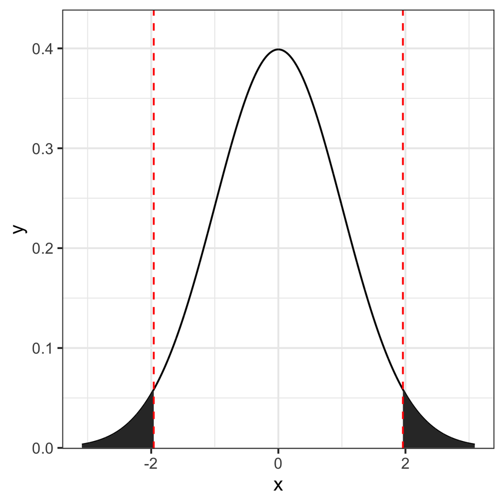

So,

$$
`\begin{aligned}
  1-\alpha &= P(-z_{\alpha/2} \le Z \le z_{\alpha/2}) \\
           & \\
           &= P\left(-z_{\alpha/2} \le \frac{P - \pi}{\sqrt{P(1-P)/n}} \le z_{\alpha/2}\right) \\
           & \\
           &= P\left(-z_{\alpha/2}\sqrt{P(1-P)/n} \le P - \pi \le z_{\alpha/2}\sqrt{P(1-P)/n}\right) \\
           & \\
           &= P\left(-P - z_{\alpha/2}\sqrt{P(1-P)/n} \le - \pi \le - P + z_{\alpha/2}\sqrt{P(1-P)/n}\right) \\
           & \\
           &= P\left(P + z_{\alpha/2}\sqrt{P(1-P)/n} \ge \pi \ge P - z_{\alpha/2}\sqrt{P(1-P)/n}\right) \\
           & \\
           &= P\left(P - z_{\alpha/2}\sqrt{P(1-P)/n} \le \pi \le P + z_{\alpha/2}\sqrt{P(1-P)/n}\right)
\end{aligned}`
$$

So, a `\((1-\alpha)\cdot 100\%\)` Confidence Interval for the true population proportion `\(\pi\)` is `\([P - z_{\alpha/2}\sqrt{P(1-P)/n}, P + z_{\alpha/2}\sqrt{P(1-P)/n}]\)`.

Say we observe `\(10\)` files with errors and `\(40\)` files without.

Our estimate would be `\(p =\)`

`\(\frac{1}{50}\sum_{i=1}^n x_i = \frac{1}{50}(10\cdot 1 + 40 \cdot 0) = 0.2\)`.

The estimated SD would be `\(\sqrt{p(1-p)/n} = \sqrt{0.2\cdot 0.8/50} \approx 0.057\)`.

So a `\(95\%\)` CI for the true population proportion has lower limit

$$
  p - z_{\alpha/2}\widehat{\text{SD}}(P) = 0.2 - 1.96 \cdot 0.057 = 0.089
$$

and upper limit

$$
  p + z_{\alpha/2}\widehat{\text{SD}}(P) = 0.2 + 1.96 \cdot 0.057 = 0.311
$$

There's a pretty strong pattern here: if `\(\bar{X}\)` is normally distributed, then a `\((1-\alpha)\cdot 100\%\)` CI for the true value of `\(E(\bar{X})\)` (which is also the true value of `\(E(X_i)\)`) is

* `\(\bar{X} \pm z_{\alpha/2} \widehat{\text{SD}}(\bar{X})\)` if calculating `\(\bar{X}\)` gives us `\(\widehat{\text{SD}}(\bar{X})\)` "for free",

* `\(\bar{X} \pm t_{\alpha/2} \widehat{\text{SD}}(\bar{X})\)` if we still need to estimate `\(\widehat{\text{SD}}(\bar{X})\)`.

This "average `\(\pm\)` critical value `\(\times\)` standard deviation" pattern comes up all the time.

True distribution:

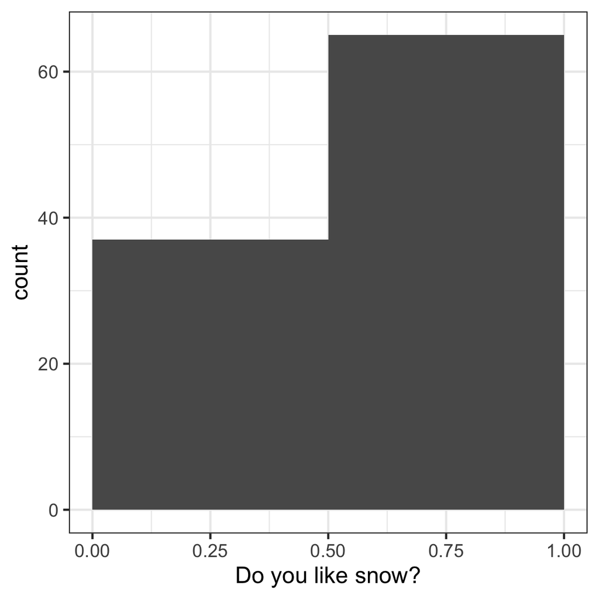

Not normal because:

* not symmetrical

* not even continuous!!!

Say we didn't have the entire population data. Just a sample of 20 students:

$$
1, 1, 0, 0, 0, 1, 1, 1, 1, 0, 0, 0, 1, 1, 0, 0, 1, 0, 1, 1
$$

Estimated propotion: `\(p = \frac{11}{20} = 0.55\)`.

Estimated standard deviation of `\(P\)`: `\(\widehat{\text{SD}}(P) = \sqrt{p(1-p)/n} = \sqrt{0.55\cdot 0.45/20} = 0.111\)`.

So a `\(95\%\)` CI is `\(0.55 \pm 1.96 \cdot 0.111 = [0.332, 0.768]\)`.

For once, we know the truth: 0.637.

Let's repeat the process many, many times. Actually, I redo this 5000 times!

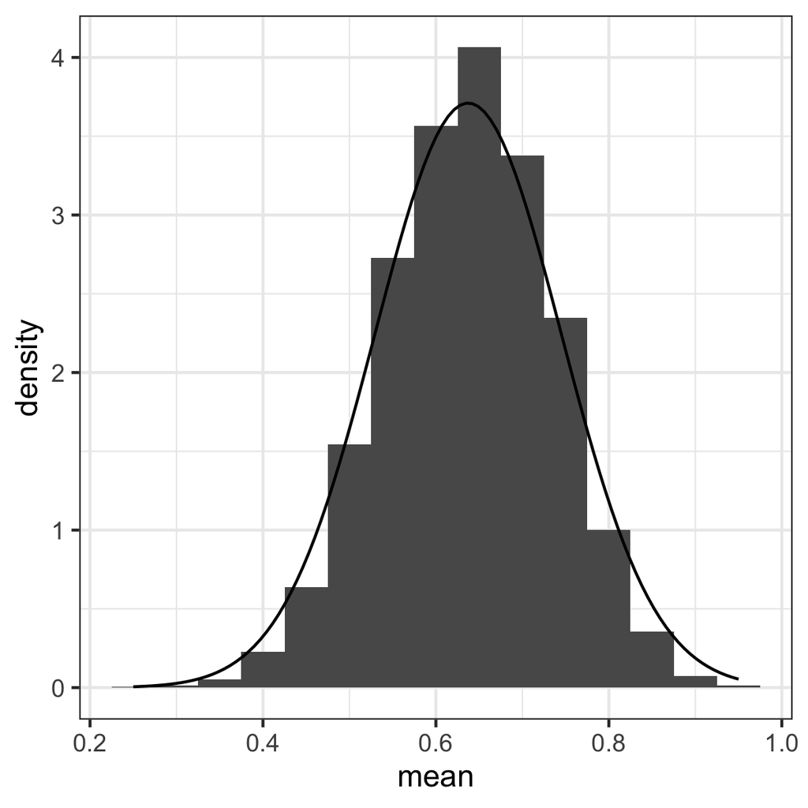

If the confidence interval correct, it should contain the true value 95% of the time. Here are the first 100:

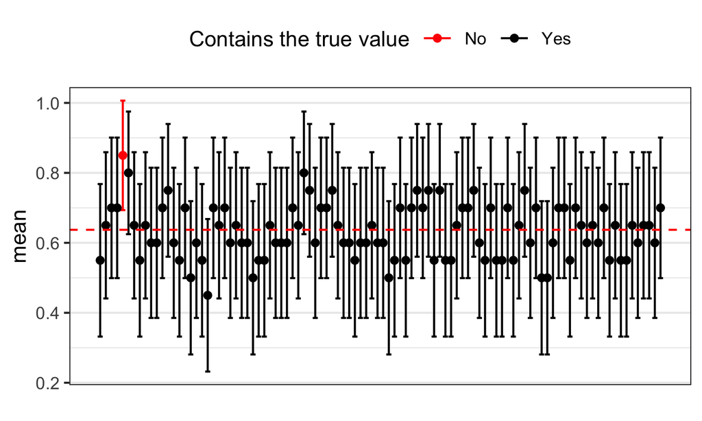

Proportion of all 5000 CIs containing the true value: 0.963. Pretty good!

True distribution:

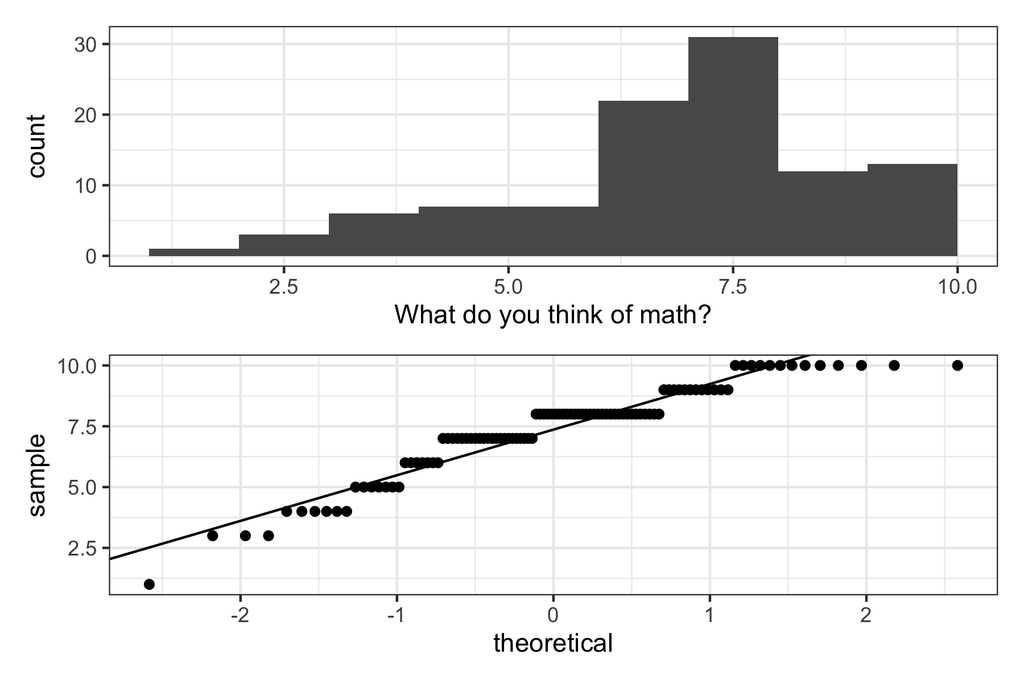

Not normal because:

* not symmetrical (left skewed)

* not even continuous!!!

Say we didn't have the entire population data. Just a sample of 20 students:

$$
10, 8, 8, 7, 4, 10, 10, 8, 8, 8, 8, 7, 7, 8, 8, 1, 8, 8, 4, 8
$$

Estimated mean: `\(\bar{x} = 7.4\)`.

Estimated standard deviation of `\(\bar{X}\)`: `\(\widehat{\text{SD}}(\bar{X}) = 0.4834379\)`.

For once, we know the truth: 7.363.

Let's repeat the process many, many times. Actually, I redo this 5000 times!

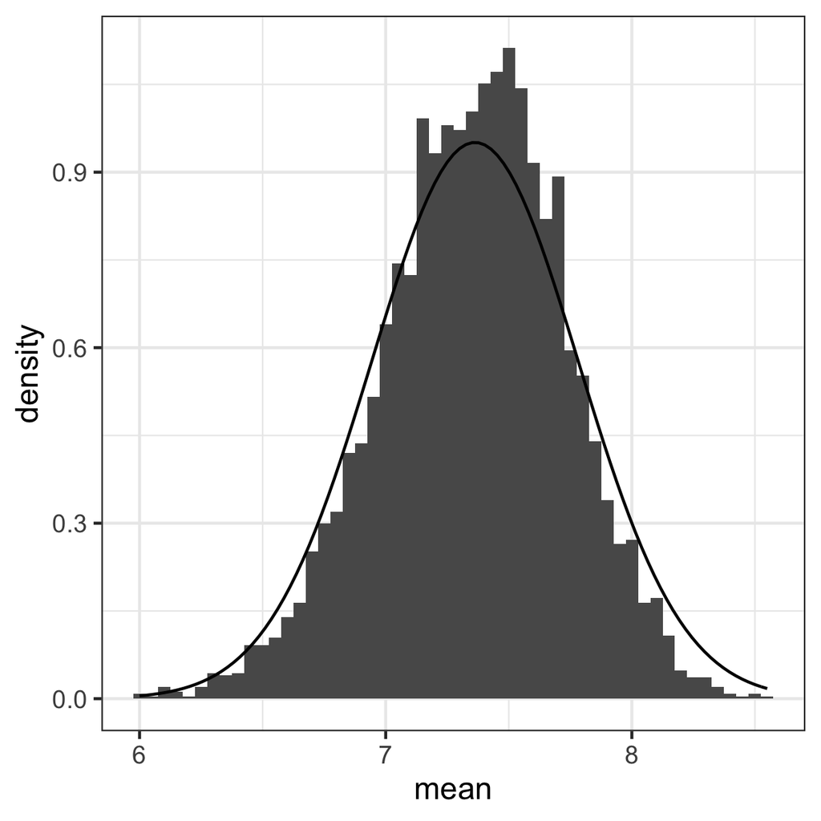

If the confidence interval correct, it should contain the true value 95% of the time. Here are the first 100:

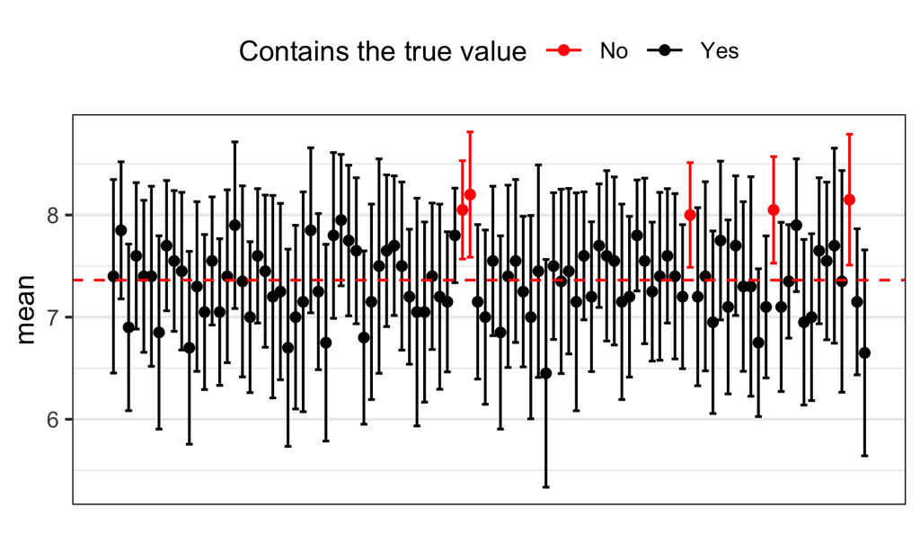

Proportion of all 5000 CIs containing the true value: 0.949. Pretty good!

# Confidence Intervals: Summary I

It is all about finding an estimator for parameter of interest, and finding the distribution of that estimator. To find the distribution, the Central Limit Theorem is a powerful ally.

* If data are from a normal distribution and `\(\sigma\)` known: `\(\bar{X} \sim N\)` and `\(\bar{X} \pm z_{\alpha/2}\text{SD}(\bar{X})\)` contains the true value of `\(E(X_i)\)` `\((1-\alpha)\cdot 100\%\)` of the time
    * `\(\text{SD}(\bar{X}) = \sigma/\sqrt{n}\)`

* If data are from a normal distribution and `\(\sigma\)` unknown: `\(\bar{X} \sim N\)` and `\(\bar{X} \pm t_{n-1,\alpha/2}\widehat{\text{SD}}(\bar{X})\)` contains the true value of `\(E(X_i)\)` `\((1-\alpha)\cdot 100\%\)` of the time
    * `\(\widehat{\text{SD}}(\bar{X}) = S/\sqrt{n} = \frac{\sqrt{\frac{1}{n-1} \sum_{i=1}^n (X_i - \bar{X})^2}}{\sqrt{n}}\)`

# Confidence Intervals: Summary II

* If data are binary, and `\(n\)` "large enough": `\(P \sim N\)` and `\(P \pm z_{\alpha/2}\widehat{\text{SD}}(P)\)` contains the true value of `\(E(X_i)\)` `\((1-\alpha)\cdot 100\%\)` of the time
    * `\(\widehat{\text{SD}}(P) = \sqrt{P(1-P)/n}\)`
    * `\(n\)` is large enough if `\(n\cdot \pi > 5\)` and `\(n\cdot (1-\pi) > 5\)`.
    * We check this using the estimated value of `\(\pi\)`, i.e. `\(p\)`. So we check if `\(n\cdot p > 5\)` and `\(n\cdot (1-p) > 5\)`.

* If data are NOT from a normal distribution, and `\(n\)` "large enough": `\(\bar{X} \sim N\)` and `\(\bar{X} \pm t_{n-1,\alpha/2}\widehat{\text{SD}}(\bar{X})\)` contains the true value of `\(E(X_i)\)` `\((1-\alpha)\cdot 100\%\)` of the time
    * `\(\widehat{\text{SD}}(\bar{X}) = S/\sqrt{n} = \frac{\sqrt{\frac{1}{n-1} \sum_{i=1}^n (X_i - \bar{X})^2}}{\sqrt{n}}\)`
    * usually, `\(n \ge 30\)` satisfies `\(n\)` "large enough"